# Data Visualization Assignment 4

#### Cluster composition for k=3:

Since, there is no clear indication of k, exploring the data and looking how the cluster is formed within documents for k=3.

From the below word cloud we can see that, K=3 dosent fit well. All 3 clusters contains mixed words related to different areas. In addition, we can predict that for the large document collection k amy be more than 3.This is also supported by elbow method.

Word cloud corresponding to 3 clusters and its frequency bar plot is plotted below.

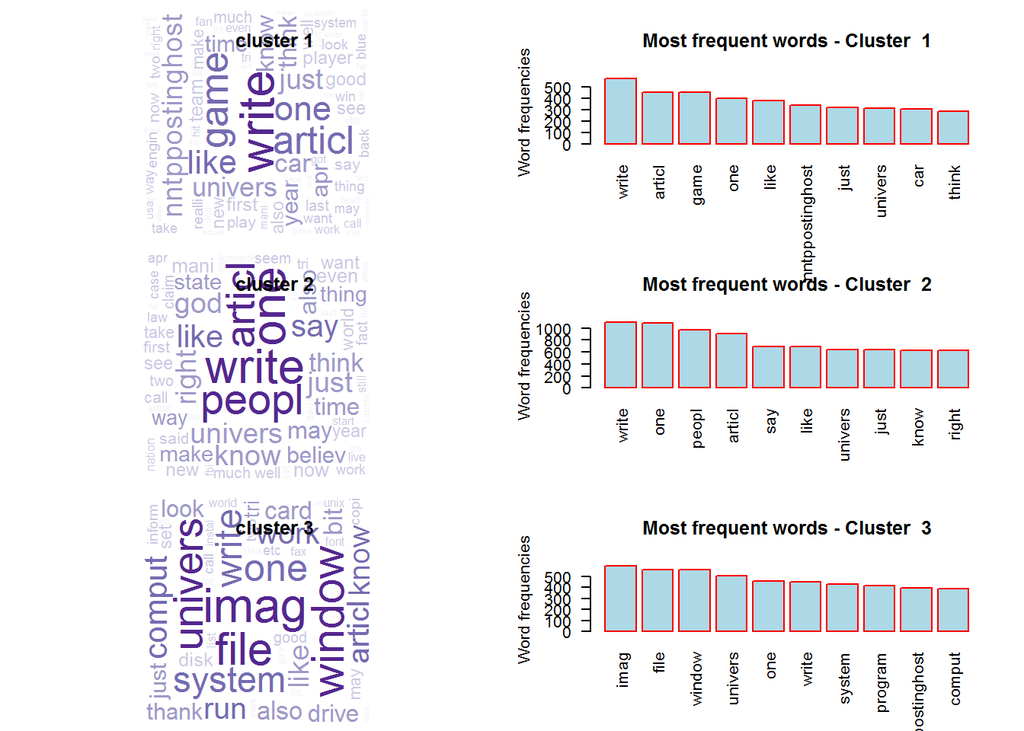

```r
corpus1.tdm <- TermDocumentMatrix(corpus1, control =
                                   list(weighting = function(x) weightTf(x)))
corpus1.tdm<-removeSparseTerms(corpus1.tdm, 0.999)
corpus1.tdm.sample <- corpus1.tdm[, rownames(corpus1.dtm.mat.sample)]
corpus1.tdm.sample.mat <- corpus1.tdm.sample %>% as.matrix()

m<- length(unique(corpus1.dtm.mat.sample.skm$cluster))
set.seed(99)
par(mfrow=c(m,2))


for (i in 1:m) {
  stp.words <- c("can", "will", "get", "line", "use", "organ", "subject", 'lines', 'organization')

  #the documents in  cluster i
  cluster_doc_ids <-which(corpus1.dtm.mat.sample.skm$cluster==i)

  #the subset of the matrix with these documents
  corpus1.tdm.sample.mat.cluster<- corpus1.tdm.sample.mat[, cluster_doc_ids]

  # sort the terms by frequency for the documents in this cluster
  v <- sort(rowSums(corpus1.tdm.sample.mat.cluster),decreasing=TRUE)
  d <- data.frame(word = names(v),freq=v)
  rw_nm <- setdiff(rownames(d), stp.words)
  d <- d[rw_nm, ]

  # call word cloud function
  wordcloud(words = d$word, freq = d$freq, scale=c(3,.1), min.freq = 1,
            max.words=200, random.order=FALSE, rot.per=0.35,
            colors=c('#f2f0f7','#cbc9e2','#9e9ac8','#756bb1','#54278f'))
  title(paste("cluster", i))


  barplot(d[1:10,]$freq, las = 1, names.arg = d[1:10,]$word,
          col ="lightblue", main =paste("Most frequent words - Cluster ", i),
          ylab = "Word frequencies", width = 0.05, border = "red", las=2)
}
```

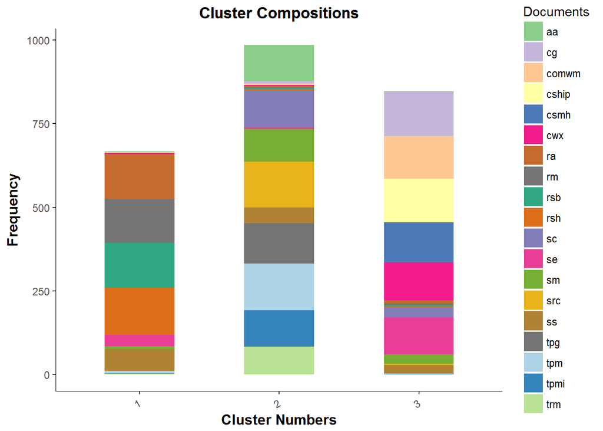

```r
g<- ggplot(corpus1.dtm.mat.sample.skm.table, aes(x=Var1, y=Freq,fill=Var2))
g<- g + geom_bar(width = 0.5, stat="identity", alpha=0.9) +
  xlab("Cluster Numbers") +
  ylab("Frequency") +
  ggtitle("Cluster Compositions")+
  scale_fill_manual(name = "Documents",values = col_vector)+
  guides(fill=guide_legend(title="Documents"))+
  theme(panel.grid.major = element_blank(),
        panel.background = element_blank(),
        axis.line = element_line(colour = "black", size = 0.25),
        axis.text.x = element_text(angle = 30, hjust=1, vjust = .5),
        legend.key = element_rect(fill = NA, colour = NA, size = 0.25),
        plot.title = element_text(hjust = 0.5, face = "bold"),
        axis.title = element_text(color="black", face="bold", size=12))

g
```

### Hierarchical Clustering and selecting the optimum height:

Since k means is not suitable for the given corpus - proceeding with the hierarchical clustering.

Moreover, we can take 19 clusters same as the number of sub corpus but there is no strong evidence to consider 19 clusters (from kmeans elbow method). Furthermore, 11 clusters divides the given corpus into reasonable clusters which can be observed and validated from word cloud.

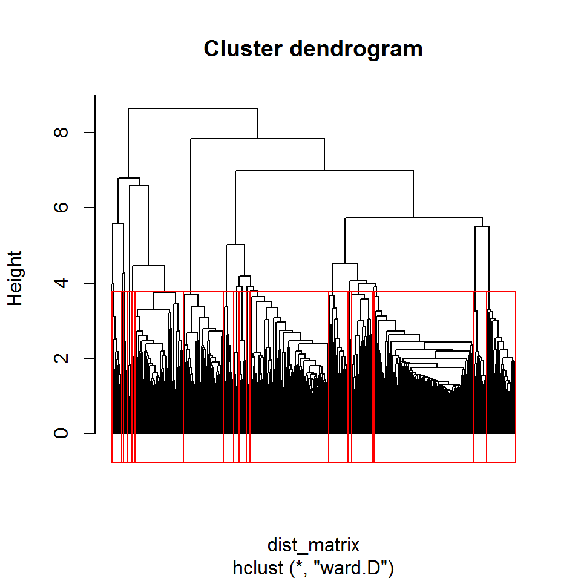

```r
sim_matrix<-distance(corpus1.dtm.mat.sample, method = "cosine")
colnames(sim_matrix) <- rownames(corpus1.dtm.mat.sample)
rownames(sim_matrix) <- rownames(corpus1.dtm.mat.sample)

dist_matrix <- as.dist(1-sim_matrix)

corpus.dtm.sample.dend <- hclust(dist_matrix, method = "ward.D")

set.seed(99)
plot(corpus.dtm.sample.dend, hang= -1, labels = FALSE,  main = "Cluster dendrogram", sub = NULL, xlab = NULL, ylab = "Height")
# here rect.hclust creates  rectangles around the dendogram for k number of clusters
rect.hclust(corpus.dtm.sample.dend, h = 3.8, border = "red")
```

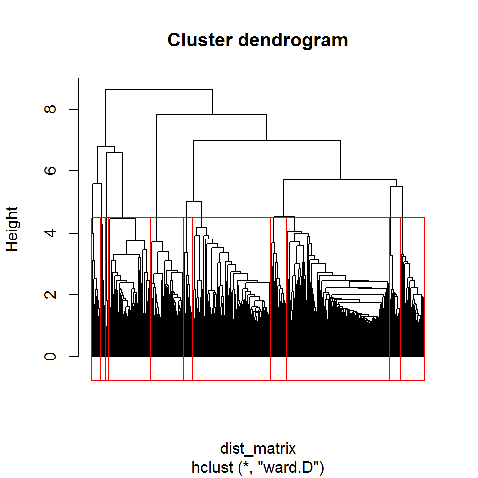

```r
plot(corpus.dtm.sample.dend, hang= -1, labels = FALSE,  main = "Cluster dendrogram", sub = NULL, xlab = NULL, ylab = "Height")
# here rect.hclust creates a rectangles around the clusters existing at a given height, h
rect.hclust(corpus.dtm.sample.dend, k = 11, border = "red")
```

```r
dendroNetwork(corpus.dtm.sample.dend, height = 800, width = 600, fontSize = 7, linkColour = "#d95f0e", nodeColour = "#fff", nodeStroke = "#d95f0e",
              textColour = c("#2ca25f", "#8856a7", "Red", "#e34a33", "#dd1c77", "#2c7fb8",
                             "#fff7bc", "#bcbddc", "#fee6ce", "#bdbdbd", "#a6bddb")
              [cutree(corpus.dtm.sample.dend, 11)], textOpacity = 0.5, textRotate = NULL,
              opacity = 0.9, margins = NULL, linkType = c("elbow", "diagonal"),
              treeOrientation = c("vertical", "horizontal"), zoom = TRUE)
```

[interactive chart not shown]

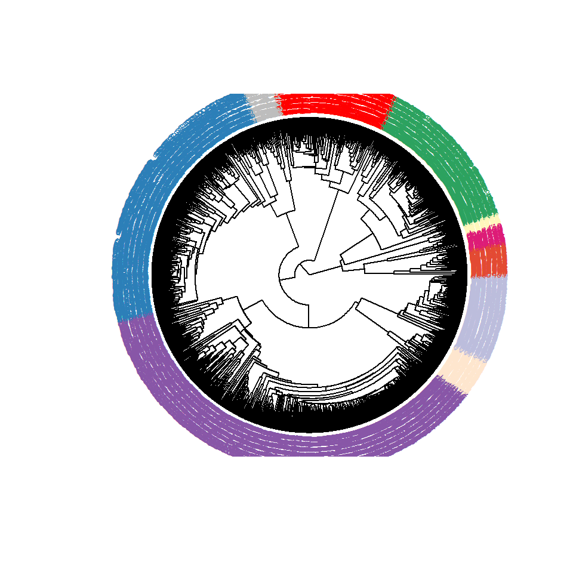

```r
colors = c("#2ca25f", "#8856a7", "Red", "#e34a33", "#dd1c77", "#2c7fb8",
           "#fff7bc", "#bcbddc", "#fee6ce", "#bdbdbd", "#a6bddb")
clus = cutree(corpus.dtm.sample.dend, 10)
plot(as.phylo(corpus.dtm.sample.dend),  type = "fan", tip.color = colors[clus],
     label.offset = 0.1, cex = 0.5)
```

### Final Clusters Selected (k=11):

Before proceeding with the word cloud we will have a quick look at high frequency words in different sub corpus. To do this first we need to remove the stop words like Subject, From, To, Line, Organization etc from the words collection because these high frequency words contains in all the documents and dosent help in differentiating the clusters.

Then cut the tree for k=11 and plotting the word clouds.

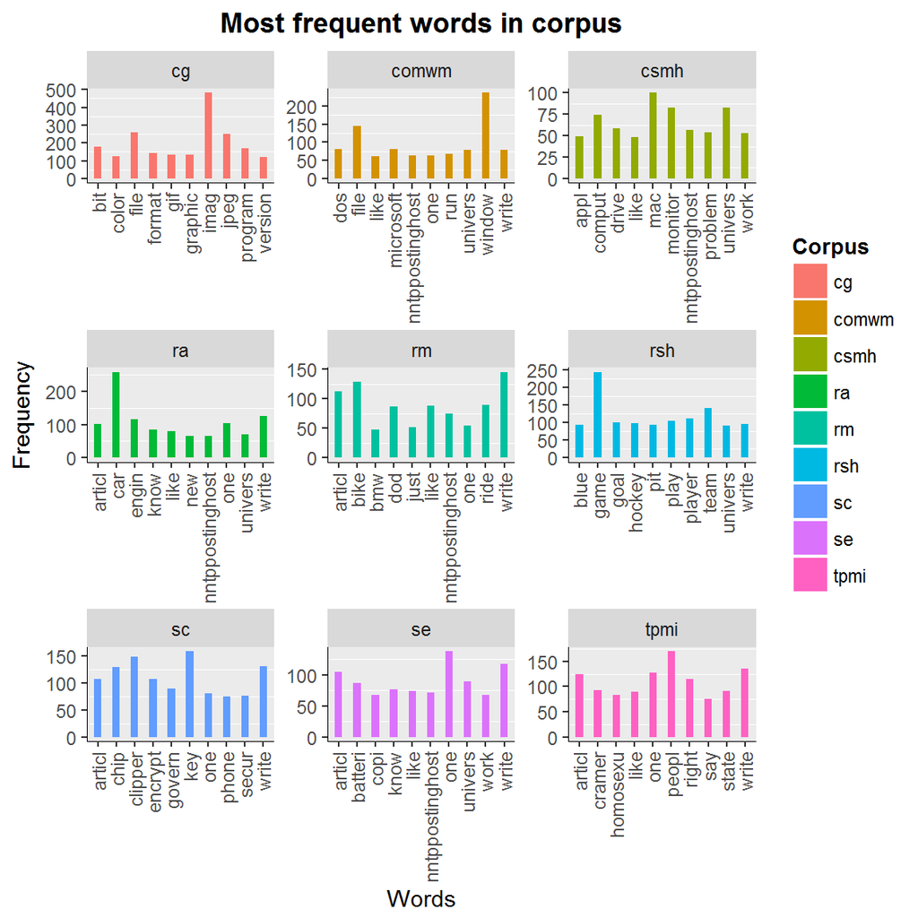

```r
k=11
corpus.dtm.sample.dend.cut <- cutree(corpus.dtm.sample.dend, k=k)
m <- length(unique(corpus.dtm.sample.dend.cut))

corpus.dtm.sample.dend.cut <- as.data.frame(corpus.dtm.sample.dend.cut)
colnames(corpus.dtm.sample.dend.cut) = c("cluster")

corpus.dtm.sample.dend.cut$docs <- rownames(corpus.dtm.sample.dend.cut)


corpus.dtm.sample.dend.cut$docs<-lapply(corpus.dtm.sample.dend.cut$docs, function(x) gsub("doc", "", x))
corpus.dtm.sample.dend.cut$docs <- unlist(corpus.dtm.sample.dend.cut$docs)

x = corpus.dtm.sample.dend.cut$docs

corpus.dtm.sample.dend.cut$docs <- as.numeric(x)



library(dplyr)
corpus.dtm.sample.dend.cut <- corpus.dtm.sample.dend.cut %>%
  mutate(doc = case_when(
    .$docs >= 1 & .$docs <= 319 ~ "aa",
    .$docs >= 320 & .$docs <= 708 ~ "cg",
    .$docs >= 709 & .$docs <= 1102 ~ "comwm",
    .$docs >= 1103 & .$docs <= 1494 ~ "cship",
    .$docs >= 1495 & .$docs <= 1879 ~ "csmh",
    .$docs >= 1880 & .$docs <= 2274 ~ "cwx",
    .$docs >= 2275 & .$docs <= 2670 ~ "ra",
    .$docs >= 2671 & .$docs <= 3068 ~ "rm",
    .$docs >= 3069 & .$docs <= 3465 ~ "rsb",
    .$docs >= 3466 & .$docs <= 3864 ~ "rsh",
    .$docs >= 3865 & .$docs <= 4260 ~ "sc",
    .$docs >= 4261 & .$docs <= 4653 ~ "se",
    .$docs >= 4654 & .$docs <= 5049 ~ "sm",
    .$docs >= 5050 & .$docs <= 5447 ~ "src",
    .$docs >= 5448 & .$docs <= 5841 ~ "ss",
    .$docs >= 5842 & .$docs <= 6205 ~ "tpg",
    .$docs >= 6206 & .$docs <= 6581 ~ "tpm",
    .$docs >= 6582 & .$docs <= 6891 ~ "tpmi",
    .$docs >= 6892 & .$docs <= 7142 ~ "trm"
  )
  )

corpus.dtm.sample.dend.cut <- corpus.dtm.sample.dend.cut[, -2]
corpus.dtm.sample.dend.cut.table <-table(corpus.dtm.sample.dend.cut$cluster, corpus.dtm.sample.dend.cut$doc)


par(mfrow=c(5,4))
l <- unique(corpus.dtm.sample.dend.cut$doc)
t.words <- NULL
for (i in 1:length(l)){
  stp.words <- c("can", "will", "get", "line", "use", "organ", "subject", "from", "to", 'lines', 'organization')
  id <-which(corpus.dtm.sample.dend.cut$doc==l[i])
  pop.words.mat <- corpus1.tdm.sample.mat[, id]
  pop.words <- sort(rowSums(pop.words.mat),decreasing=TRUE)
  wd <- data.frame(word = names(pop.words),freq=pop.words)
  rw_nm <- setdiff(rownames(wd), stp.words)
  wd <- wd[rw_nm, ]
  wd$source <- l[i]
  t.words <- rbind(t.words, wd[1:10, ])
}


subset1 <- t.words[t.words$source %in% c("rsh", "cg", "csmh", "tpmi", "rm", "sc", "se", "ra", "comwm"), ]
ggplot(subset1, aes(x=word, y=freq, fill=source))+geom_bar(stat="identity", width = 0.4)+
  facet_wrap(~source, scales = "free")+
  ggtitle("Most frequent words in corpus")+
  xlab("Words")+
  ylab("Frequency")+
  theme(panel.grid.major = element_blank(),
        #panel.background = element_blank(),
        axis.line = element_line(colour = "black", size = 0.25),
        axis.text.x = element_text(angle = 90, hjust=1, vjust = .5),
        legend.key = element_rect(fill = NA, colour = NA, size = 0.25),
        plot.title = element_text(hjust = 0.5, face = "bold"),
        legend.title=element_text(size=10, face = "bold"))+
  guides(fill=guide_legend(title="Corpus"))
```

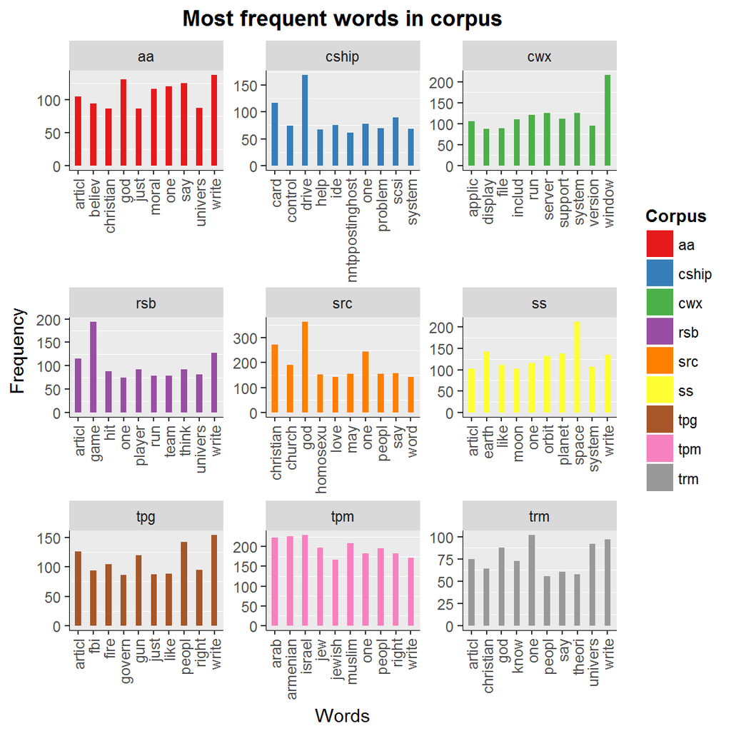

```r
subset2 <- t.words[t.words$source %in% c("ss", "cwx", "src", "aa", "cship", "tpm", "rsb", "tpg", "trm"), ]
ggplot(subset2, aes(x=word, y=freq, fill=source))+
  geom_bar(stat="identity", width = 0.4)+
  facet_wrap(~source, scales = "free")+
  ggtitle("Most frequent words in corpus")+
  xlab("Words")+
  ylab("Frequency")+
  scale_fill_brewer(palette="Set1")+
  theme(panel.grid.major = element_blank(),
        axis.line = element_line(colour = "black", size = 0.25),
        axis.text.x = element_text(angle = 90, hjust=1, vjust = .5),
        legend.key = element_rect(fill = NA, colour = NA, size = 0.25),
        plot.title = element_text(hjust = 0.5, face = "bold"),
        legend.title=element_text(size=10, face = "bold"))+
  guides(fill=guide_legend(title="Corpus"))
```

### Cluster Composition, confusion matrix and word clouds:

From word clouds, we can see all the clusters word cloud is reasonably well which covers different areas of the documents. Further, explanation on clusters is given in Inference from clusters section.

```r
#displays the confusion matrix
corpus.dtm.sample.dend.cut.table
```

```
##
##       aa  cg comwm cship csmh cwx  ra  rm rsb rsh  sc  se  sm src  ss tpg
##   1   82   5     0     2    0   3   1   3   0   1   4   3   3 125   7   2
##   2    4   0     2     0    0   1   5   0   0   0   1   1   0   3  92   1
##   3   21  25    14    26   20  19 120 128  38  14  40  65 119  15  26  19
##   4    0   0     2     4    1   0   8   0 100 128   1   1   2   0   0   2
##   5    0   0     0     0    0   0   0   0   0   0   0   0   0   0   0   0
##   6    0   0     0     0    0   0   0   0   0   0   0   0   0   0   0   0
##   7    2 108   103    70   85  95  12   5   2   3  15  64   8   0   9   2
##   8    0   0     0     0    0   0   0   0   0   0   0   0   0   0   0   0
##   9    1   2     0     1    1   1   3   1   3   0   2   2   2   0   0  97
##   10   1   0     0     1    0   0   0   0   0   0  79   0   0   0   0   0
##   11   0   0     9    29   14   0   0   1   0   0   0  11   0   0   0   0
##
##      tpm tpmi trm
##   1   15    5  56
##   2    0    5   2
##   3   27   26  14
##   4    0    0   0
##   5   64    0   1
##   6   37    1   0
##   7    2    1   1
##   8    0   25   0
##   9    1   48  14
##   10   0    1   0
##   11   0    0   0
```

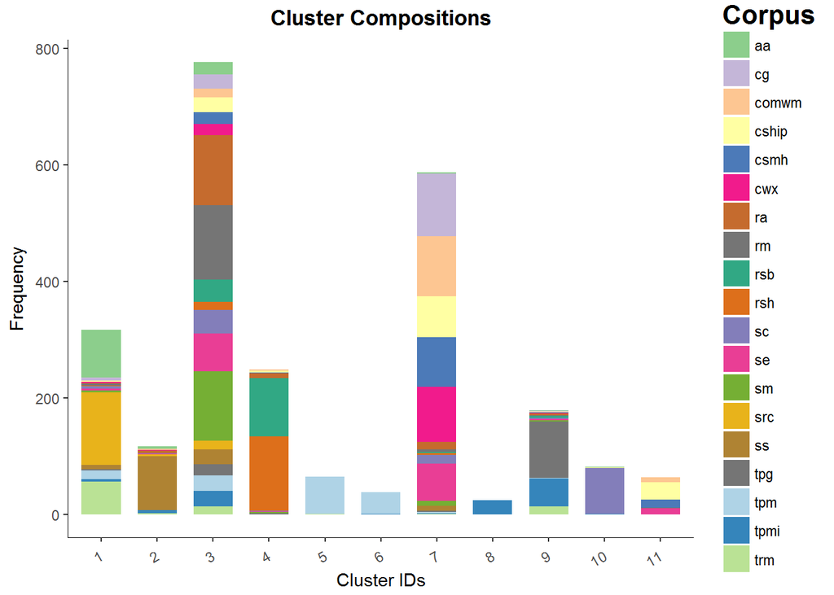

```r
corpus.dtm.sample.dend.cut.table <-as.data.frame.table(corpus.dtm.sample.dend.cut.table)

# plot stacked bar graph to show cluster compositions
g<- ggplot(corpus.dtm.sample.dend.cut.table, aes(x=Var1, y=Freq, fill=Var2))
g<- g + geom_bar(stat="identity", width = 0.7, alpha=0.9) +
  xlab("Cluster IDs") +
  ylab("Frequency") +
  ggtitle("Cluster Compositions")+
  scale_fill_manual(name = "Documents",values = col_vector)+
  guides(fill=guide_legend(title="Corpus"))+
  theme(panel.grid.major = element_blank(),
        panel.background = element_blank(),
        legend.title = element_text(colour="black", size=16, face="bold"),
        axis.line = element_line(colour = "black", size = 0.25),
        axis.text.x = element_text(angle = 30, hjust=1, vjust = .5),
        legend.key = element_rect(fill = NA, colour = NA, size = 0.25),
        plot.title = element_text(hjust = 0.5, face = "bold"))

g
```

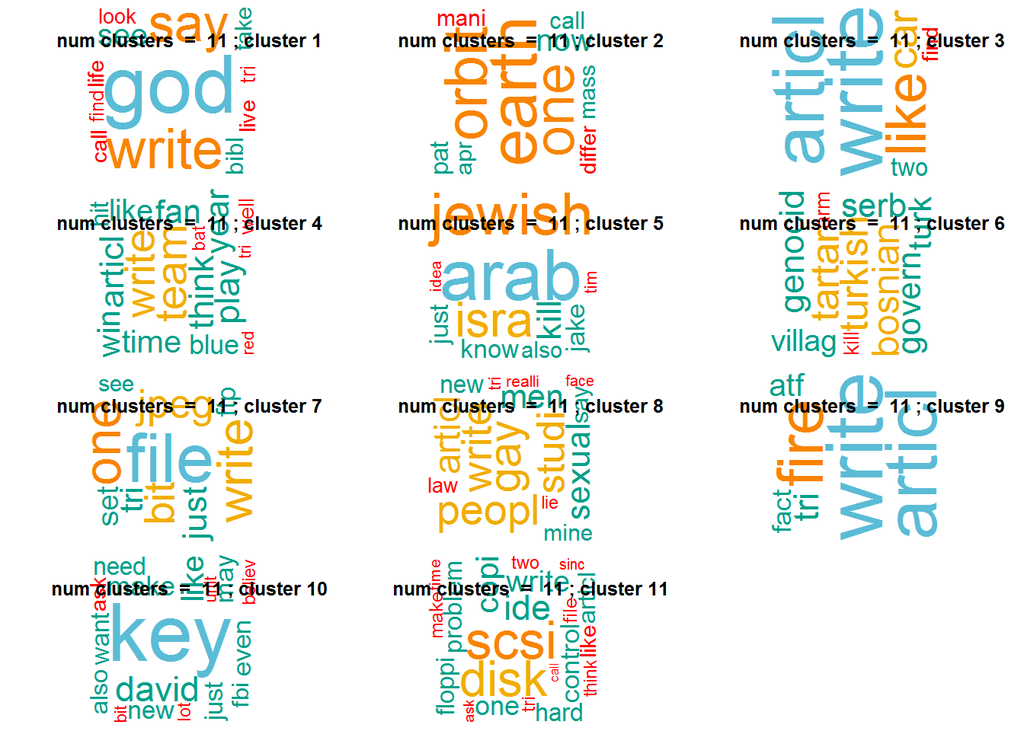

```r
m <- length(unique(corpus.dtm.sample.dend.cut$cluster))
set.seed(1478)
par(mfrow=c(4,3))

# for each cluster plot an explanatory word cloud
for (i in 1:m) {
  stp.words <- c("can", "will", "get", "line", "use", "organ", "subject", 'lines', 'organization')
  #the documents in  cluster i
  cut_doc_ids <-which(corpus.dtm.sample.dend.cut$cluster==i)

  #the subset of the matrix with these documents
  corpus.tdm.sample.mat.cluster<- corpus1.tdm.sample.mat[, cut_doc_ids]

  # sort the terms by frequency for the documents in this cluster
  v <- sort(rowSums(corpus.tdm.sample.mat.cluster),decreasing=TRUE)
  d <- data.frame(word = names(v),freq=v)
  rw_nm <- setdiff(rownames(d), stp.words)
  d <- d[rw_nm, ]
  # call word cloud function
  word.cloud.dt <- data.frame(words=d$word, Freq=d$freq)
  #wordcloud2(word.cloud.dt, size=1, color='random_dark', #backgroundColor="#bdbdbd")

  wordcloud(words = d$word, freq = d$freq, scale=c(5,.5), min.freq = 5,
            max.words=100, random.order=FALSE, rot.per=0.7,
            colors=wes_palette("Darjeeling"))
  title(main = paste("num clusters  = ", k, "; cluster", i), outer = FALSE)
}
```

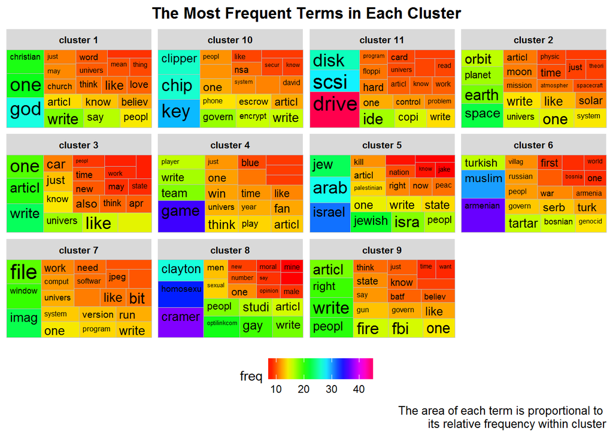

```r
# number of terms per cluster to show
n <-20
#intialise an empty data frame fields initiliased with empty vectors
df <- data.frame(word=character(), freq = double(),cluster = integer())
# for each cluster plot an explanatory word cloud
for (i in 1:m) {
  stp.words <- c("can", "will", "get", "line", "use", "organ", "subject", 'lines', 'organization')
  #the documents in  cluster i
  cut_doc_ids <-which(corpus.dtm.sample.dend.cut$cluster==i)

  #the subset of the matrix with these documents
  corpus.tdm.sample.mat.cluster<- corpus1.tdm.sample.mat[, cut_doc_ids]

  # sort the terms by frequency for the documents in this cluster
  v <- sort(rowSums(corpus.tdm.sample.mat.cluster),decreasing=TRUE)
  d <- data.frame(word = names(v),freq=v, cluster=i)
  rw_nm <- setdiff(rownames(d), stp.words)
  d <- d[rw_nm, ]

  # we might want scale so that high frequencies in large cluster don't predominate
  d[,2] <- scale(d[,2],center=FALSE, scale=TRUE)

  # take first n values only
  d <-d[1:n,]

  #bind the data for this cluster to the df data frame created earlier
  df<- rbind(df,d)
}
# the geom_treemap seems to only like vectors of values
df$freq <- as.vector(df$freq)

# simple function to rename the values in the cluster column as "cluster 1, cluster 2, etc"
clust_name<-function(x){
  paste("cluster", x)
}

# apply the function to the 'cluster' column
df$cluster<- as.character(apply(df["cluster"], MARGIN = 2,FUN =clust_name ))
gg<- ggplot(df, aes(area = freq, fill = freq, subgroup=cluster, label = word)) +
  geom_treemap() +
  geom_treemap_text(grow = T, reflow = T, colour = "black") +
  facet_wrap( ~ cluster) +
  scale_fill_gradientn(colours = rainbow(n, s = 1, v = 1, start = 0, end = max(1, n - 1)/n, alpha = 1))+
  theme(legend.position = "bottom",
        strip.text.x = element_text(size = 8, colour = "black", face="bold"),
        plot.title = element_text(hjust = 0.5, face = "bold") )+
  labs(title = "The Most Frequent Terms in Each Cluster",
       caption = "The area of each term is proportional to
       its relative frequency within cluster")

gg
```

### Cluster Composition Sunburst:

Sunbusrt gives the clear idea of number of clusters and how many number of documents within a sub corpus for a given cluster. Note: the number of documnets within each subcorpus is displayed as percentage.

```r
library(sunburstR)
cl <- corpus.dtm.sample.dend.cut
# Preparing the data set which is suitable to give to sunburts.
cl$doc_id <- rownames(cl)
cl$cluster <- paste("Cluster", cl$cluster, sep="-")
gp <- cl %>% dplyr::group_by(cluster, doc) %>% dplyr::summarize(cnt = n())
gp$seq <- do.call(paste, c(gp[c("cluster", "doc")], sep = "-"))
sun <- gp[ ,c("seq", "cnt")]
sunburst(sun, count=TRUE, withD3 = TRUE)
```

[interactive chart not shown]

### Inference From Clustors:

Final Number of Clusters = 11

##### Cluster 1 - Related to god, church, people (Spiritual):

The documents in this cluster is about articles related to God, christians, church and people’s beliefs.

##### Cluster 2 - Earth and Space Science:

This cluster is mainly about universe, space shuttle, and sapce missions. We can say that this cluster is related to earth and space science.

##### Cluster 3 - News articles current affairs:

This cluster is about current affairs like news articles.

##### Cluster 4 - Games:

This cluster mainly contains Games, play, teams, win and loose.

##### Cluster 5 - Related to Israel, Palestanian and arabs:

From the above word cloud we can see that this cluster contains text regarding Jewish people in Israel, palestatnian and arab countries.

##### Cluster 6 - Muslims, Turkish, Russian and Bosnian war:

This cluster is may be people or articles about bosnian war and involvement of Turkish, russians, americans in bosnian war etc.

##### Cluster 8 - study of sexuality - morale:

This cluster contains mainly about the articles about sexuality of the people Gay, homosexual, male, female etc.

##### Cluster 9 - FBI, crime cases, guns, fire, government:

This cluster contains articles about FBI cases, firearm, peoples rights, government related issues.

##### Cluster 10 - Security NSA:

This cluster contains mainly anbout like chips, clipper, key, encrypt and related to govenment or nsa i.e. security related issues.

##### Cluster 11 - Computer components:

This cluster contains electronic components like Drive, disk, floppy, memory cards etc.